# Enron Email Database Statistical Analysis Report

Charles Manil

2025-05-12

# 1 **Introduction**

In this study case we sill analyze a major scandal of fraud and financial manipulation that occured in 2001 the **Enron Scandal**. **Enron** was one of the major (if not the biggest) energy company from the late 90’s. During their fall, they took with them one of the big 5 (now down to four): **Andersen**. The Enron affair gave rise to an unprecedented number of official investigations, legal actions and media reactions around the world. The disaster had serious consequences for more than 26,000 employees and some 45,000 investors.

In order to analyze this case, we will focus on the email data set, which was obtained by the **Federal Energy Regulatory Commission** during its investigation of Enron’s collapse. The original version contains around 500,000 records, but the data set provided in this analysis is a pre-processed one containing 252759 usable entries.

We will do this analysis in a *R Shiny* application, that will allow us to retrieve quick graphs and statistic in order for us to interpret data. Even if the data set is pre-processed, we will still need to handle some kinds of errors in order for the analysis to be consistent. The analysis will be structured as it follow :  
1. We will first make a *temporal analysis* to see the behaviors of the email exchanges through the scandal.  
2. We will then try to see if the *status of an employee* in the company affect the exchange he will make through this vector of communication.  
3. We will try to *analyze the content* of the exchange, are they longer regarding different hypothesis, is the content different regarding those too ?  
4. We will establish a *network of relations* between the employee to see if a pattern emerges.  
5. We will finish with some statistics on the data set and try to establish a *regression model* to see if we could predict some features of the data set.

## 1.1 **Loading of the dataset**

The pre-processed data set has been provided in the file *“Enron.Rdata”*. We will first load it in Rstudio in order to retrieve it and work on it.

```r
#Loading of the database. Please replace my_path value with the path of your file. Use a local emplacement to store it, One Drive users may occur errors. Otherwise just access and clone the repo : https://github.com/Jacquart08/EnronMail_R_ShinyApp

my_path <- "C:/Users/CM_LAPTOP/Downloads/Enron.Rdata"
load(my_path)

# Load required packages
library(ggplot2) #plotting tool
library(dplyr) #for the data manipulation
library(stringr) #string manipulation in the content and emails
library(lubridate) #help dealing with dates
library(wordcloud) #for the word cloud
library(tm) #for the text mining
library(visNetwork) #for the network visualization
library(tidytext) # also for the text mining
library(tibble) #easy row by row reader
library(knitr) #dynamic report edition
```

In case you are using the full data set provided on : https://www.cs.cmu.edu/~enron/ , you will then need to extract the *.tar.gz* with the `untar(my_path, exdir="Your/desired/path)` function. See [R documentation](https://www.rdocumentation.org/packages/utils/versions/3.6.2/topics/untar) for more informations.

# 2 **First step in the Dataset**

Let’s gather some information about the different data frames we loaded previously. We are writing very simple code in order to retrieve all the columns of the data frames and their data types.

```r
str(employeelist)
```

```
## 'data.frame':    149 obs. of  9 variables:
##  $ eid      : num  13 6 19 115 129 18 33 149 52 21 ...
##  $ firstName: chr  "Marie" "Mark" "Lindy" "Lisa" ...
##  $ lastName : chr  "Heard" "Taylor" "Donoho" "Gang" ...
##  $ Email_id : chr  "marie.heard@enron.com" "mark.e.taylor@enron.com" "lindy.donoho@enron.com" "lisa.gang@enron.com" ...
##  $ Email2   : chr  "" "mark.taylor@enron.com" "ldonoho@enron.com" "" ...
##  $ Email3   : chr  "" "e.taylor@enron.com" "" "" ...
##  $ EMail4   : chr  "" "" "" "" ...
##  $ folder   : chr  "heard-m" "taylor-m" "donoho-l" "gang-l" ...
##  $ status   : Factor w/ 10 levels "CEO","Director",..: NA 3 3 7 1 2 7 3 3 2 ...
```

```r
str(message)
```

```
## 'data.frame':    252759 obs. of  5 variables:
##  $ mid       : int  52 53 54 55 56 57 58 59 60 61 ...
##  $ sender    : Factor w/ 17527 levels "-persson@ricemail.ricefinancial.com",..: 13252 12358 12358 13252 12358 5565 5088 2900 2868 2361 ...
##  $ date      : Date, format: "2000-01-21" "2000-01-24" ...
##  $ message_id: Factor w/ 252759 levels "<10000282.1075847198841.JavaMail.evans@thyme>",..: 20268 164410 44339 4329 50733 181388 129861 111357 132891 248375 ...
##  $ subject   : chr  "ENRON HOSTS ANNUAL ANALYST CONFERENCE PROVIDES BUSINESS OVERVIEW AND GOALS FOR 2000" "Over $50 -- You made it happen!" "Over $50 -- You made it happen!" "ROAD-SHOW.COM Q4i.COM CHOOSE ENRON TO DELIVER FINANCIAL WEB CONTENT" ...
```

```r
str(recipientinfo)
```

```
## 'data.frame':    2064442 obs. of  4 variables:
##  $ rid   : int  67 68 69 70 71 72 73 74 75 76 ...
##  $ mid   : num  52 53 54 55 56 56 57 58 59 60 ...
##  $ rtype : Factor w/ 3 levels "BCC","CC","TO": 3 3 3 3 3 3 3 3 3 3 ...
##  $ rvalue: Factor w/ 68084 levels "--migrated--sgrendel@ercot.com",..: 2060 2046 2049 2060 2065 18193 10002 56479 54146 63168 ...
```

```r
str(referenceinfo)
```

```
## 'data.frame':    54778 obs. of  3 variables:
##  $ rfid     : int  2 3 8 13 14 15 16 17 18 19 ...
##  $ mid      : int  79 99 533 842 845 846 847 848 849 851 ...
##  $ reference: chr  "> From: Le Vine, Debi> Sent: Thursday, August 17, 2000 6:29 PM> To: ISO Market Participants> Subject: Request f"| __truncated__ "> From: Golden, Mark> Sent: Thursday, August 24, 2000 4:02 PM> To: Pergher, Gunther> Subject: Calif Gov Hopes T"| __truncated__ "From: Sole, JeanneS…
```

We do now know that we are against a big data base, related to the emails sent in the company **Enron** before a major incident. We do have at our disposal an employee list with the different information about the staff, the messages that those users sent via the email vector of communication. The two other tables are information about emails. We do have in the *recipientinfo* some Ids and the email address of the recipient and in the *referenceinfo* the link between the recipient and the information contained in the email (the content and the date particularly).

Let’s write the data dictionary about this data set:

| **Data Frame name** | **Column name** | **Data type** | **Key type** | **Description** |
| --- | --- | --- | --- | --- |
| **employeelist** | eid | *num* | PK | Primary key and employee id |
|  | firstName | *chr* |  |  |
|  | lastName | *chr* |  |  |
|  | Email_id | *chr* |  |  |
|  | Email2 | *chr* |  | In case an employee has several mails |
|  | … (till4) | *chr* |  |  |
|  | folder | *chr* |  |  |
|  | status | *Factor* |  | Categorical value referencing the job ob an employee |
| **message** | mid | *int* | PK | Primary key of the message data frame |
|  | sender | *Factor* |  | Categorical value based on an email address |
|  | date | *Date* |  |  |
|  | message_id | *Factor* |  | categorical value of the messages id in the archive of Enron |
|  | subject | *chr* |  | The subject of the Email |
| **recipientinfo** | rid | *int* | PK | Primary key of the recipientinfo |
|  | mid | *num* | FK | Foreign key to the message data frame |
|  | rtype | *Factor* |  | Is the recipient in the TO, CC, CCi, … |
|  | rvalue | *Factor* |  | Email address of the recipient |
| **referenceinfo** | rfid | *int* | PK | Primary key of the referenceinfo data frame |
|  | mid | *int* | FK | Foreign key to the message dataframe |
|  | reference | *chr* |  | The actual content of the Emails |

With the following we will establish a functional dependency matrix regarding the Lapage process :

| Determines → Is determined by ↓ | eid | firstName | lastName | Email_id | Email2 | folder | mid | sender | date | message_id | subject | rid | rtype | rvalue | rfid | reference | status |
| --- | --- | --- | --- | --- | --- | --- | --- | --- | --- | --- | --- | --- | --- | --- | --- | --- | --- |
| **eid** | ✔️ | ✔️ | ✔️ | ✔️ | ✔️ | ✔️ |  |  |  |  |  |  |  |  |  |  | ✔️ |
| **mid** |  |  |  |  |  |  | ✔️ | ✔️ | ✔️ | ✔️ | ✔️ | ✔️ | ✔️ | ✔️ | ✔️ | ✔️ |  |
| **rid** |  |  |  |  |  |  |  |  |  |  |  | ✔️ | ✔️ | ✔️ |  |  |  |
| **rfid** |  |  |  |  |  |  |  |  |  |  |  |  |  |  | ✔️ | ✔️ |  |

Some simple analysis can be quickly achieved, and with it we will have a better overview of the data.

We do have written all the relations existing between our data. This processes will simplify later the analysis and the behavior of the features in the data frames. This can be particularly useful if we are planning further implementation of ML algorithm.

Later we are going to visualize some simple one to one relations that appear in the database, let’s try to focus first on the employee list info.

## 2.1 **Employeelist univariate analysis**

Let’s try to identify more precisely how the data set is composed in term of employees. This will be performed by the basic count formula $Count(s)= \sum^N _{i=1}1(status_i = s) \ | \ Knowing \ that \ s =each \ individual \ status$

```r
table(employeelist$status)
```

```
##
##               CEO          Director          Employee   In House Lawyer
##                 4                14                41                 1
##           Manager Managing Director               N/A         President
##                14                 3                31                 4
##            Trader    Vice President
##                13                23
```

So it seems that we do have a proper distribution to make clear and precise analysis. The N/A values are not usable as we can’t have those information online. We will keep them as they can be useful in a future network analysis so we will not get rid of them during the data cleaning.

## 2.2 **Preparatory data cleaning**

Lets first create an email_data table that will contain the count of emails monthly.

```r
# Create a data frame with monthly email counts
email_data <- data.frame(
  Date = as.Date(paste0(format(message$date, "%Y-%m"), "-01")),
  Count = 1
)

# Group by Date and summarize the count to see how many email by month
email_data <- email_data %>%
  group_by(Date) %>%
  summarize(Count = sum(Count))

head(email_data)
```

```
## # A tibble: 6 × 2
##   Date       Count
##   <date>     <dbl>
## 1 0001-05-01     2
## 2 0001-06-01     1
## 3 0001-07-01     1
## 4 0001-08-01    12
## 5 0001-09-01     9
## 6 0001-10-01    62
```

We do notice that several of dates are not usable due to some mistakes. We identify that the first one is that *0001* and *0002* are induced instead of *2001* and *2002*. We then see a *1979* instead of *1997*. For the year *2020*, it seems indeed to be an email from *2002*. The messages from *2044* and *2043* don’t have records by checking by message ID (mid). As we don’t have the content we will not convert them we will simply remove them.

```r
# Correct errors in the year data in the dataframe
email_data <- email_data %>%
  # Correct years 0001 and 0002 to 2001 and 2002, 1979 to 1997 and 2020 to 2002
  mutate(Date = case_when(
    format(Date, "%Y") == "0001" ~ as.Date(paste0("2001", format(Date, "-%m-%d"))),
    format(Date, "%Y") == "0002" ~ as.Date(paste0("2002", format(Date, "-%m-%d"))),
    format(Date, "%Y") == "1979" ~ as.Date(paste0("1997", format(Date, "-%m-%d"))),
    format(Date, "%Y") == "2020" ~ as.Date(paste0("2002", format(Date, "-%m-%d"))),
    TRUE ~ Date
  ))

# Filtering the data set in order to show only the relevant period (1999 and 2002 in our case)
email_data <- email_data[email_data$Date >= as.Date("1999-01-01") & email_data$Date <= as.Date("2002-12-31"), ]


# Display the data with corrected years
head(email_data)
```

```
## # A tibble: 6 × 2
##   Date       Count
##   <date>     <dbl>
## 1 2001-05-01     2
## 2 2001-06-01     1
## 3 2001-07-01     1
## 4 2001-08-01    12
## 5 2001-09-01     9
## 6 2001-10-01    62
```

```r
# Display summary statistics
summary(email_data)
```

```
##       Date                Count
##  Min.   :1999-01-01   Min.   :    1.0
##  1st Qu.:2000-03-08   1st Qu.:   50.5
##  Median :2001-05-01   Median :  667.0
##  Mean   :2001-01-29   Mean   : 4355.3
##  3rd Qu.:2001-12-01   3rd Qu.: 7435.2
##  Max.   :2002-12-01   Max.   :29556.0
```

Now that the data is clean lets visualize it with some plots.

## 2.3 **Temporal analysis of the messages**

We will here perform a simple time series aggregation in order to count how many emails were send each month. For each month m we will compute $Count(m)=\sum^N_{i=!}1(month(date_i)=m)$

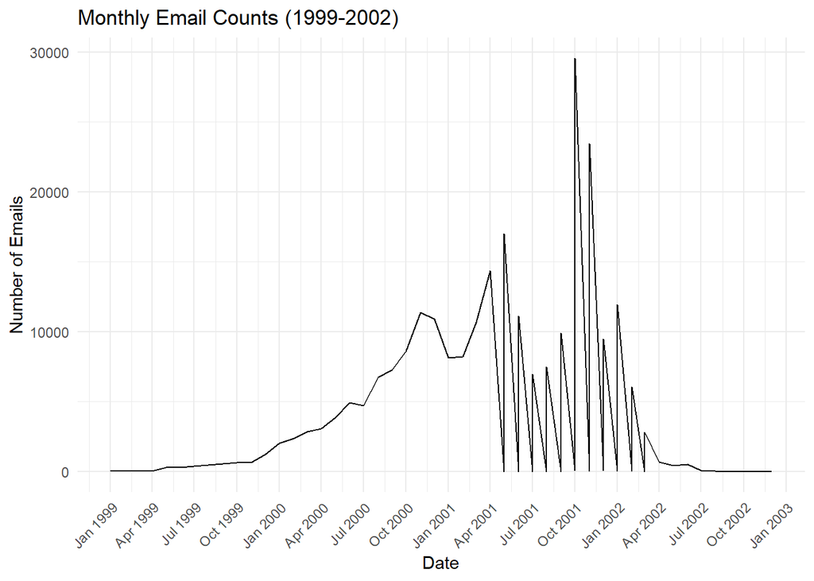

Figure 2.1: Monthly Email Count

```r
# Create the time series plot
ggplot(email_data, aes(x = Date, y = Count)) +
  geom_line() +
  labs(title = "Monthly Email Counts (1999-2002)",
       x = "Date",
       y = "Number of Emails") +
  theme_minimal() +
  scale_x_date(date_breaks = "3 months", date_labels = "%b %Y") +
  theme(axis.text.x = element_text(angle = 45, hjust = 1))
```

We do notice that in Figure 2.1 the the number of email exchanges followed an exponential growth trend until October 2001, before rapidly collapsing until April 2002. If we are relating those data to the actual context of the company. The In fact in August 2001, the CEO if the company declares that *“The company is probably the strongest and best shape that it has ever been in”* although it wasn’t true and the Enron Broadband Services was reporting losses. The artificial value of the company was due to a falsified financial package.

**Enron**’s share price, after rising sharply until 2000, fell sharply in 2000-2001. While these loans served as collateral for numerous financial arrangements between the company and its banks, the latter demanded repayment of these camouflaged loans, which resurfaced on the company’s balance sheet.

In October 2001, **Enron** CEO is asking for the Secretary of Commerce to use his influence on the quotation agency **Moody**’s and later this month **Security and Exchange’s Commission** raise a case. Quickly in December 2001 the company declare its bankruptcy.

## 2.4 **Role analysis regarding the echanges**

In this part we will focus on the message data frame. We will try to identify who is the most active email sender of this data set. Here the count il also a basic count formula for each sender s $EmailSent(s)=\sum^N_{i=1}(sender_i=s)$

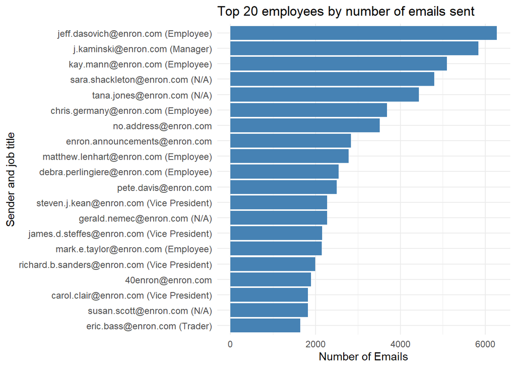

Figure 2.2: The 20 employees who sent the most emails and their status

```r
# This part count the number of emails a sender has
top_senders <- message %>%
  count(sender, sort = TRUE)

# Join the status information with the email address (correspond to the profession of the employee)
top_senders <- top_senders %>%
  left_join(employeelist, by = c("sender" = "Email_id")) %>%
  mutate(
    label = ifelse(!is.na(status),
                   paste0(sender, " (", status, ")"),
                   sender)
  )

# Plot this information
top_senders %>%
  slice_max(n, n = 20) %>%
  ggplot(aes(x = reorder(label, n), y = n)) +
  geom_col(fill = "steelblue") +
  coord_flip() +
  labs(
    title = "Top 20 employees by number of emails sent",
    x = "Sender and job title",
    y = "Number of Emails"
  ) +
  theme_minimal() +
  theme(axis.text.y = element_text(size = 9))
```

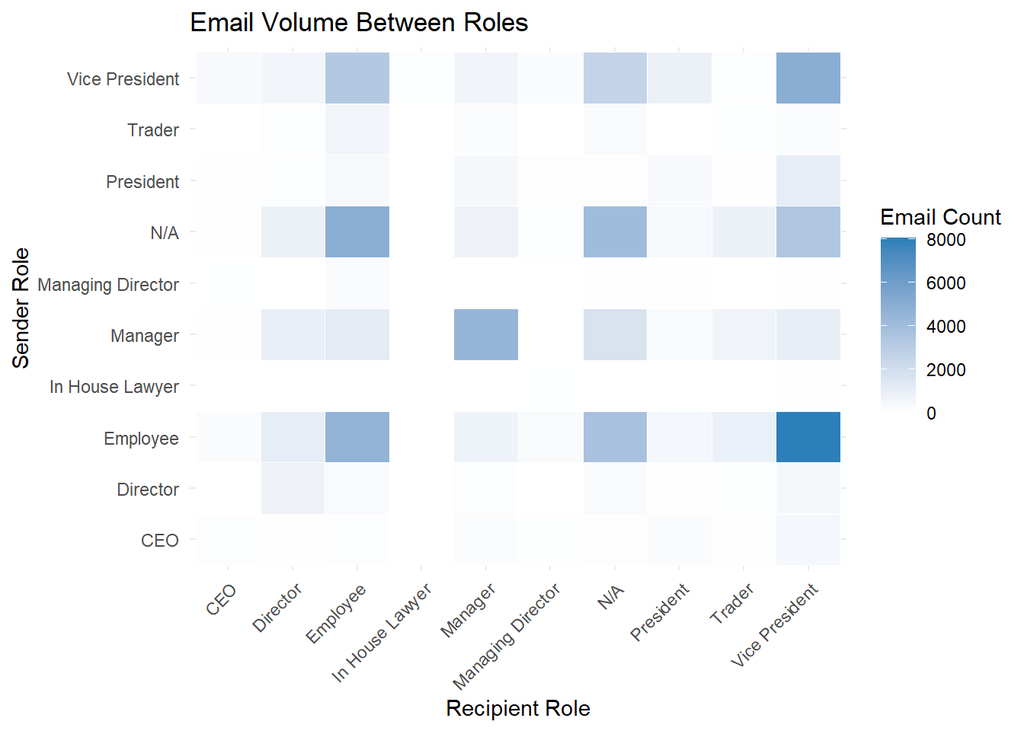

Figure 2.3: Role to Role Heatmap regarding the email exchanges

```r
# Clean and standardize sender email addresses in the message data
message <- message %>%
  mutate(sender_email = tolower(trimws(sender)))

# Clean and standardize employee email addresses
employeelist <- employeelist %>%
  mutate(emp_email = tolower(trimws(Email_id)))

# Get sender and recipient roles from employee list
sender_roles <- employeelist %>%
  select(emp_email, sender_status = status)

recipient_roles <- employeelist %>%
  select(emp_email, recipient_status = status)

# Create sender-recipient pairs with roles
role_pairs <- recipientinfo %>%
  mutate(rvalue_clean = tolower(trimws(rvalue))) %>%  # Clean email addresses
  left_join(message %>% select(mid, sender_email), by = "mid") %>%
  left_join(sender_roles, by = c("sender_email" = "emp_email")) %>%
  left_join(recipient_roles, by = c("rvalue_clean" = "emp_email")) %>%
  filter(!is.na(sender_status) & !is.na(recipient_status))  # Keep only complete pairs

# Count number of emails between role combinations
heatmap_data <- role_pairs %>%
  count(sender_status, recipient_status) %>%
  tidyr::pivot_wider(names_from = recipient_status, values_from = n, values_fill = 0)

# Convert to matrix for heatmap
mat <- as.matrix(heatmap_data[,-1])
rownames(mat) <- heatmap_data$sender_status

# Convert matrix to long format for ggplot
heatmap_df <- as.data.frame(as.table(mat))
colnames(heatmap_df) <- c("Sender Role", "Recipient Role", "Count")

# Plot heatmap
ggplot(heatmap_df, aes(x = `Recipient Role`, y = `Sender Role`, fill = Count)) +
  geom_tile(color = "white") +
  scale_fill_gradient(low = "white", high = "#2c7fb8") +
  labs(
    title = "Email Volume Between Roles",
    x = "Recipient Role",
    y = "Sender Role",
    fill = "Email Count"
  ) +
  theme_minimal() +
  theme(axis.text.x = element_text(angle = 45, hjust = 1))
```

# 3 **In depth analysis**

In this section we will go deeper into the data set. We will *analyse the content* of the email as well as the *networking* appearing in the exchanges. We will then relate it the some *statistical analysis* in order later to try to introduce some *simple regression models*.

## 3.1 **Message content analysis**

Due to the actual construction of the data frame *referenceinfo*, where the content of the emails is stored, we do have inside lot of useless information. In fact it record all the email with the information about the sender, the recipient, the subject, … but all of those information are already stored into the *recipientinfo* data frame. I’ve tried in the app to perform a regex to remove the headers. Due to the number of emails and the ressources I have at my disposal I can’t afford to make it run. The function was `referenceinfo <- referenceinfo %>% mutate(message_body = str_replace(reference, ".*?\r?\n\r?\n", ""))` but *message_body* took too long to complete. I will stick with **reference*, knowing that the analysis will be altered.

Despite the data is altered by the email content headers, the N-gram plot is still relevant. In fact, if we put aside the headers redundancy in all the different employees, we still notice that some contacts are coming in the n-2, meaning that a network graph will be a good idea.

In Figure 3.1 we do see that we have a huge redundancy od privacy related patterns. Indeed the words “intended recipient” associated sometimes with negations implicate that such expressions are not only frequent but also formulaic. They follow a legal or corporate template aiming to disclaim responsibility or assert confidentiality.

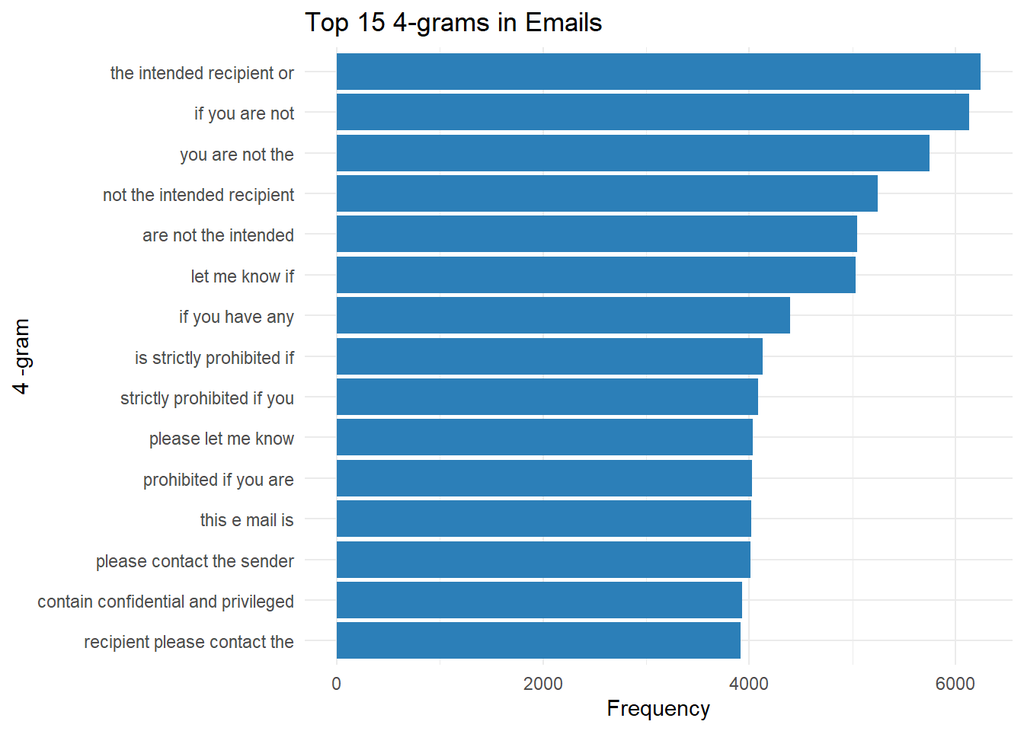

```r
# Join to get messages with reference text
sender_messages <- message %>%
  left_join(referenceinfo, by = "mid") %>%
  pull(reference) %>%
  as.character()

# Put everything into a tibble
text_df <- tibble(text = sender_messages)

# Define fallback values in case shiny inputs are not present
if (!exists("ngram_n")) ngram_n <- 4
if (!exists("ngram_top")) ngram_top <- 15

# Generate top N n-grams
ngrams <- text_df %>%
  unnest_tokens(ngram, text, token = "ngrams", n = ngram_n) %>%
  count(ngram, sort = TRUE) %>%
  filter(!is.na(ngram)) %>%
  slice_max(n, n = ngram_top)

# Plot the result (can be long to render due to the actual computation)
ggplot(ngrams, aes(x = reorder(ngram, n), y = n)) +
  geom_col(fill = "#2c7fb8") +
  coord_flip() +
  labs(
    title = paste("Top", ngram_top, paste0(ngram_n, "-grams"), "in Emails"),
    x = paste(ngram_n, "-gram"),
    y = "Frequency"
  ) +
  theme_minimal()
```

## 3.2 **Network visualization of the exchanges**

As seen in the *N-gram plot* (more relevant in the app as we can explore the data set with customs inputs), some employees have in their 2-gram, some full names are appearing. This induce some stronger connections between some employees. In Figure 3.2 we do see that no real pattern shows up regarding the network bu it is still interesting to notice the exchanges especially if we focus on the princial fuctions of the company (*eg. CEO or Director*)

```r
# Nodes: Each employee as a node
nodes <- employeelist %>%
  mutate(id = emp_email, # id is the email address so we can use it to connect the nodes
         label = paste(firstName, lastName), # label is the full name of the employee
         group = status) %>% # group is the status of the employee
  select(id, label, group)

# Edges: Email connections between employees
edges <- recipientinfo %>%
  mutate(rvalue_clean = tolower(trimws(rvalue))) %>%
  left_join(message %>% select(mid, sender_email), by = "mid") %>% # left join the message data with the recipientinfo data because not in the same DF
  left_join(employeelist %>% select(emp_email, Email_id), by = c("sender_email" = "emp_email")) %>% # same as above
  mutate(from = sender_email, to = rvalue_clean) %>% # from is the sender and to is the recipient
  filter(!is.na(from) & !is.na(to)) %>% # filter out the NAs as we have some
  filter(from %in% nodes$id & to %in% nodes$id) %>%
  group_by(from, to) %>%
  summarize(value = n(), .groups = "drop")

# Simple count of emails
total_emails <- nrow(message)

cat(paste0("### Total Emails: ", total_emails))
```

```
## ### Total Emails: 252759
```

```r
# Parameter of the network (number of connections)
# As you can see on the app, it is not readable above 150
max_edges <- 150

# Sample the edges in order to reduce the overhelming of too much lines
edges_sample <- edges %>% sample_n(min(nrow(edges), max_edges))

# Plot visualization with colors to identify the status and the legend
visNetwork(nodes, edges_sample) %>%
  visEdges(smooth = FALSE, width = "value") %>%
  visOptions(highlightNearest = TRUE, nodesIdSelection = TRUE) %>%
  visGroups(groupname = "CEO", color = "red") %>%
  visGroups(groupname = "Director", color = "orange") %>%
  visGroups(groupname = "Manager", color = "blue") %>%
  visGroups(groupname = "Employee", color = "green") %>%
  visLegend()
```

[interactive chart not shown]

Figure 3.2: Network visualization of the exhanges

If looking at some individuals in the network, we do see that Jeff Dasovich, for instance, had a clear link to the CEO Jeffrey skilling but also with the different vice president, director or even employees.

## 3.3 **Hypothesis testing**

By playing with the t-test render on the Shiny App, we do notice that there is a lot of variation of the value of t regarding the different status of an employee. So there is a big difference of average length of the emails regarding the role. It may suggest that the actual average length of an email can be estimated doing some regression or even further if introduction Machine Learning algorithm.

## 3.4 **Linear regression on variables**

```r
#Data cleaning, ensuring one more time that they are consistent
#I have way less value type error in R than in Pyhton so may be overkill
dat <- message %>%
  left_join(referenceinfo, by = "mid") %>%
  left_join(employeelist, by = c("sender_email" = "emp_email")) %>%
  mutate(email_length = str_length(reference),
         status = as.factor(status))

# Linear regression model
fit <- lm(email_length ~ status, data = dat)

# model summary
summary(fit)
```

```
##
## Call:
## lm(formula = email_length ~ status, data = dat)
##
## Residuals:
##    Min     1Q Median     3Q    Max
##  -1900  -1167   -686    264  64033
##
## Coefficients:
##                         Estimate Std. Error t value Pr(>|t|)
## (Intercept)               1192.9      144.9   8.234  < 2e-16 ***
## statusDirector             146.9      160.5   0.915 0.360119
## statusEmployee             706.8      148.3   4.764  1.9e-06 ***
## statusIn House Lawyer      476.6      189.0   2.521 0.011695 *
## statusManager              422.9      151.1   2.798 0.005145 **
## statusManaging Director    371.0      269.2   1.378 0.168116
## statusN/A                  329.5      149.0   2.211 0.027077 *
## statusPresident            309.3      163.4   1.893 0.058384 .
## statusTrader               148.6      165.2   0.899 0.368661
## statusVice President       533.1      149.3   3.571 0.000356 ***
## ---
## Signif. codes:  0 '***' 0.001 '**' 0.01 '*' 0.05 '.' 0.1 ' ' 1
##
## Residual standard error: 2824 on 30238 degrees of freedom
##   (222511 observations deleted due to missingness)
## Multiple R-squared:  0.004239,   Adjusted R-squared:  0.003943
## F-statistic:  14.3 on 9 and 30238 DF,  p-value: < 2.2e-16
```

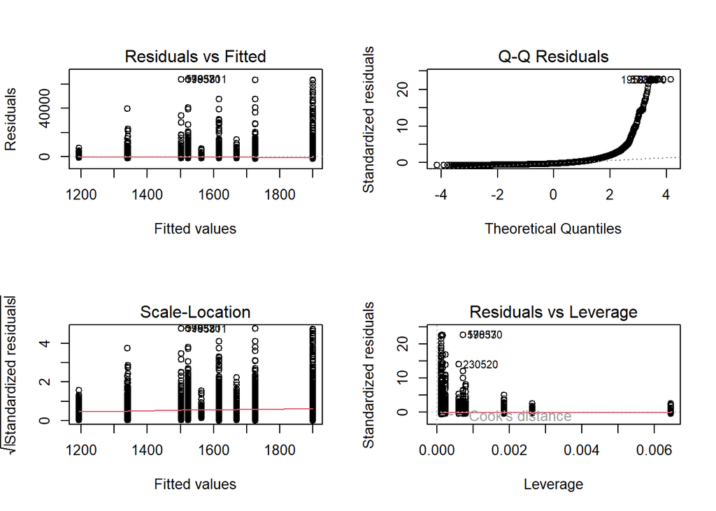

Figure 3.3: Linear regression on email length depending on the status

```r
# Diagnostic plot
par(mfrow = c(2, 2))
plot(fit)
```

## 3.5 **Clustering and outlier detection**

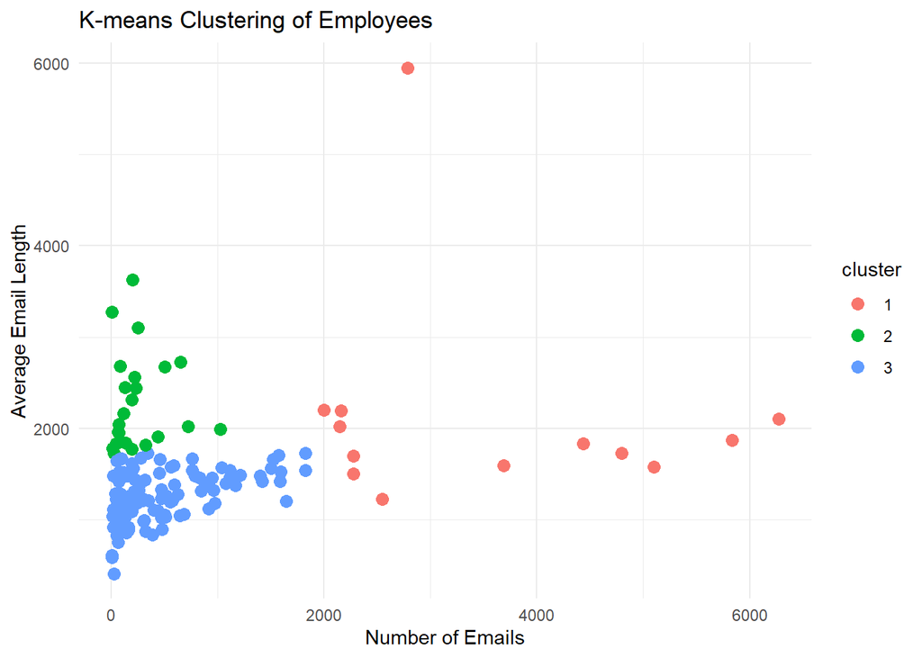

Figure 3.4: K means clustering of the employees

```r
# Define number of clusters
cluster_k <- 3  # Change this value as needed

# Join and summarize data
dat <- message %>%
  left_join(referenceinfo, by = "mid") %>%
  left_join(employeelist, by = c("sender_email" = "emp_email")) %>%
  mutate(email_length = str_length(reference)) %>%
  group_by(sender_email, status) %>%
  summarize(
    n_emails = n(),
    avg_length = mean(email_length, na.rm = TRUE),
    .groups = "drop"
  ) %>%
  na.omit()

  # Apply k-means
km <- kmeans(dat[, c("n_emails", "avg_length")], centers = cluster_k)

# Assign cluster labels
dat$cluster <- as.factor(km$cluster)

  # Plot clusters
ggplot(dat, aes(x = n_emails, y = avg_length, color = cluster)) +
  geom_point(size = 3) +
  labs(
    title = "K-means Clustering of Employees",
    x = "Number of Emails",
    y = "Average Email Length"
  ) +
  theme_minimal()
```

## 3.6 **Clustering validity: Elbow Method**

To assess the validity of the clustering and determine the optimal number of clusters, we use the elbow method. This involves plotting the total within-cluster sum of squares (WSS) for different values of k and identifying the point where the rate of decrease sharply slows (the “elbow”).

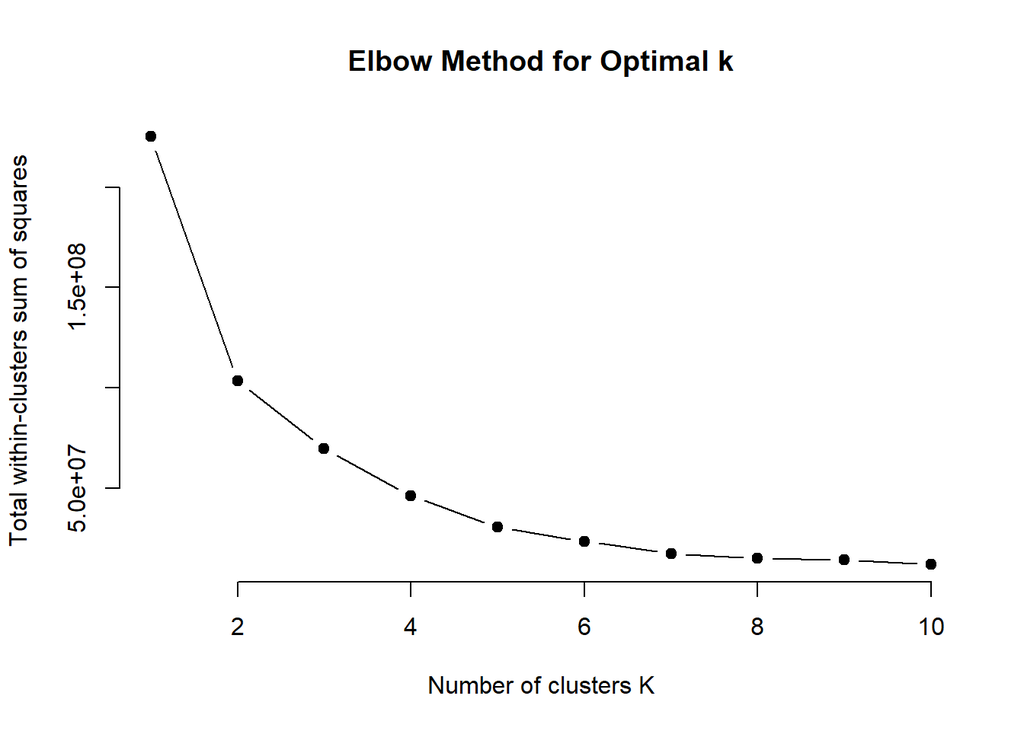

Figure 3.5: Elbow Method for Optimal k

```r
# Compute WSS for k = 1 to 10
wss <- sapply(1:10, function(k){
  kmeans(dat[, c("n_emails", "avg_length")], centers = k, nstart = 10)$tot.withinss
})

# Plot the elbow
plot(1:10, wss, type = "b", pch = 19, frame = FALSE,
     xlab = "Number of clusters K",
     ylab = "Total within-clusters sum of squares",
     main = "Elbow Method for Optimal k")
```

# 4 **Conclusion**